# Cluster Analysis

Roger Bukuru

2024-06-03

# Introduction

- Purpose: allocate item to groups
- Key characteristic: unsupervised
  - “Unsupervised” in the sense that we do not know which observations belong to groups
  - Can be used for feature extraction
    - This does not allocate observations to groups, but rather creates new varianles from the original x

What is a cluster ?

- A cluster is a set of items that are grouped together according to some criterion such as:
  - Proximity e.g k-means clustering, MDS
  - points with a lower dissimilarity are grouped together.A point (1, 0) has a lower Euclidean distance to a point (0, 1) than a point (5, 5), and so would be clustered with the (0, 1) point.
  - Probability
    - points allocated to probability distribution most likely to have generated them. Suppose point arose from either a N(0, 1) distribution or an N(5, 1) distribution. A point –1 would be allocated to cluster whose distribution matches the first.
  - Modality
    - Imagine 100 observations of one variable. If we plot the density of that variable and it has two peaks, then we could divide the data into two clusters.
  - Density
    - In a given dataset, 70% of observations lie between 0 and 1 and the remaining 30% lie between 5 and 6. The regions [0, 1] and [5, 6] are high-density regions, and points lying within those regions are clustered together.
- A cluster is generally thought of as a group of items (object, points) in which each item is “close” (in some appropriate sense) to a central item of a cluster and that members of different clusters are “far away” from each other.

There are numerous ways of clustering a data set of n independent measurements on each of r correlated variables - Clustering Observations: Mapping individual samples to a groups. The K groups is unknown and has to be determined from data - Clustering variables: Partition the $p$ variables into $K$ distinct groups, where the number K is unknown and has to be determied from the data. - Two-way clustering: Simultaneosuly cluster by observations and variables. Other names “block clustering”, “direct-clustering”, “biclustering”, or “co-clustering”.

## A few Clustering approaches

- Hierarchical
  - Agglomerative
    - Begin with each observation its own cluster, and merge clusters until one cluster
  - Divisive
    - Begin with one cluster, split until each observation is its own cluster.
- Partitioning
  - Distance-based: k-means, PAM, FANNY
  - Probability-based: clustering using Gaussian mixtures

### Hierarchical Clustering

- We tend to use a dendogram to determine the number of clusters
- Idea of Single Linkage, Complete Linkage and Average Linkage
  - Cutting dendogram at a particular height leads to partitioning into a specified number of groups
  - Height of linkage refers to similarity of objects, the lower the height of merge, the more similar the objects
  - Mathematical algorithm described in notes.

#### Example 1

```r
rm(list = ls())

library(cluster)
data = read.csv2("Ex12.3.4.csv")
agglom_single = agnes(data, metric="euclidean", stand=FALSE, method="single", trace.lev = 5)
```

```
## C agnes(n=8, method = 2, ..): 7 merging steps
##  nmerge=0, j=2, d_min = D(1,3) = 0.200000;  -> (-1,-3); last=3; upd(n,b);
##  old D(A, j), D(B, j), j=2  = (1.1,0.9);  new D(A', 2) = 0.9
##  old D(A, j), D(B, j), j=4  = (4.2,4);  new D(A', 4) = 4
##  old D(A, j), D(B, j), j=5  = (4.4,4.2);  new D(A', 5) = 4.2
##  old D(A, j), D(B, j), j=6  = (3.6,3.4);  new D(A', 6) = 3.4
##  old D(A, j), D(B, j), j=7  = (1.5,1.3);  new D(A', 7) = 1.3
##  old D(A, j), D(B, j), j=8  = (1.8,1.6);  new D(A', 8) = 1.6
##  -->  size(A_new)= 2
##  nmerge=1, j=2, d_min = D(4,5) = 0.200000;  -> (-4,-5); last=5;
##  old D(A, j), D(B, j), j=1  = (4,4.2);  new D(A', 1) = 4
##  old D(A, j), D(B, j), j=2  = (3.1,3.3);  new D(A', 2) = 3.1
##  old D(A, j), D(B, j), j=6  = (0.6,0.8);  new D(A', 6) = 0.6
##  old D(A, j), D(B, j), j=7  = (2.7,2.9);  new D(A', 7) = 2.7
##  old D(A, j), D(B, j), j=8  = (2.4,2.6);  new D(A', 8) = 2.4
##  -->  size(A_new)= 2
##  nmerge=2, j=2, d_min = D(7,8) = 0.300000;  -> (-7,-8); last=8;
##  old D(A, j), D(B, j), j=1  = (1.3,1.6);  new D(A', 1) = 1.3
##  old D(A, j), D(B, j), j=2  = (0.4,0.7);  new D(A', 2) = 0.4
##  old D(A, j), D(B, j), j=4  = (2.7,2.4);  new D(A', 4) = 2.4
##  old D(A, j), D(B, j), j=6  = (2.1,1.8);  new D(A', 6) = 1.8
##  -->  size(A_new)= 2
##  nmerge=3, j=2, d_min = D(2,7) = 0.400000;  -> (-2,3); last=7; upd(n,b);
##  old D(A, j), D(B, j), j=1  = (0.9,1.3);  new D(A', 1) = 0.9
##  old D(A, j), D(B, j), j=4  = (3.1,2.4);  new D(A', 4) = 2.4
##  old D(A, j), D(B, j), j=6  = (2.5,1.8);  new D(A', 6) = 1.8
##  -->  size(A_new)= 3
##  nmerge=4, j=2, d_min = D(4,6) = 0.600000;  -> (2,-6); last=8;
##  old D(A, j), D(B, j), j=1  = (4,3.4);  new D(A', 1) = 3.4
##  old D(A, j), D(B, j), j=2  = (2.4,1.8);  new D(A', 2) = 1.8
##  -->  size(A_new)= 3
##  nmerge=5, j=2, d_min = D(1,2) = 0.900000;  -> (1,4); last=3;
##  old D(A, j), D(B, j), j=4  = (3.4,1.8);  new D(A', 4) = 1.8
##  -->  size(A_new)= 5
##  nmerge=6, j=4, d_min = D(1,4) = 1.80000;  -> (6,5); last=6;
##  -->  size(A_new)= 8
```

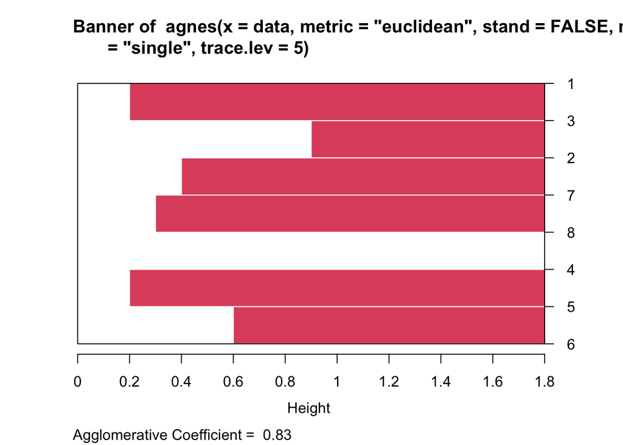

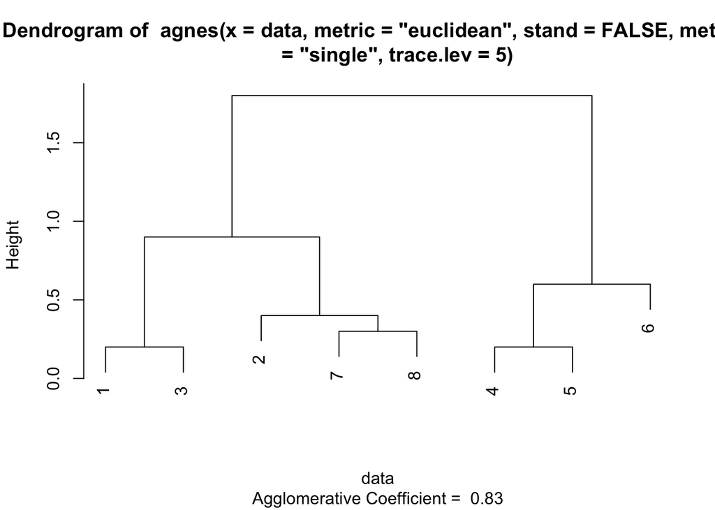

```r
plot(agglom_single)
```

```r
agglom_complete = agnes(data, metric="euclidean", stand=FALSE, method="complete", trace.lev = 5)
```

```
## C agnes(n=8, method = 3, ..): 7 merging steps
##  nmerge=0, j=2, d_min = D(1,3) = 0.200000;  -> (-1,-3); last=3; upd(n,b);
##  old D(A, j), D(B, j), j=2  = (1.1,0.9);  new D(A', 2) = 1.1
##  old D(A, j), D(B, j), j=4  = (4.2,4);  new D(A', 4) = 4.2
##  old D(A, j), D(B, j), j=5  = (4.4,4.2);  new D(A', 5) = 4.4
##  old D(A, j), D(B, j), j=6  = (3.6,3.4);  new D(A', 6) = 3.6
##  old D(A, j), D(B, j), j=7  = (1.5,1.3);  new D(A', 7) = 1.5
##  old D(A, j), D(B, j), j=8  = (1.8,1.6);  new D(A', 8) = 1.8
##  -->  size(A_new)= 2
##  nmerge=1, j=2, d_min = D(4,5) = 0.200000;  -> (-4,-5); last=5;
##  old D(A, j), D(B, j), j=1  = (4.2,4.4);  new D(A', 1) = 4.4
##  old D(A, j), D(B, j), j=2  = (3.1,3.3);  new D(A', 2) = 3.3
##  old D(A, j), D(B, j), j=6  = (0.6,0.8);  new D(A', 6) = 0.8
##  old D(A, j), D(B, j), j=7  = (2.7,2.9);  new D(A', 7) = 2.9
##  old D(A, j), D(B, j), j=8  = (2.4,2.6);  new D(A', 8) = 2.6
##  -->  size(A_new)= 2
##  nmerge=2, j=2, d_min = D(7,8) = 0.300000;  -> (-7,-8); last=8;
##  old D(A, j), D(B, j), j=1  = (1.5,1.8);  new D(A', 1) = 1.8
##  old D(A, j), D(B, j), j=2  = (0.4,0.7);  new D(A', 2) = 0.7
##  old D(A, j), D(B, j), j=4  = (2.9,2.6);  new D(A', 4) = 2.9
##  old D(A, j), D(B, j), j=6  = (2.1,1.8);  new D(A', 6) = 2.1
##  -->  size(A_new)= 2
##  nmerge=3, j=2, d_min = D(2,7) = 0.700000;  -> (-2,3); last=7; upd(n,b);
##  old D(A, j), D(B, j), j=1  = (1.1,1.8);  new D(A', 1) = 1.8
##  old D(A, j), D(B, j), j=4  = (3.3,2.9);  new D(A', 4) = 3.3
##  old D(A, j), D(B, j), j=6  = (2.5,2.1);  new D(A', 6) = 2.5
##  -->  size(A_new)= 3
##  nmerge=4, j=2, d_min = D(4,6) = 0.800000;  -> (2,-6); last=8;
##  old D(A, j), D(B, j), j=1  = (4.4,3.6);  new D(A', 1) = 4.4
##  old D(A, j), D(B, j), j=2  = (3.3,2.5);  new D(A', 2) = 3.3
##  -->  size(A_new)= 3
##  nmerge=5, j=2, d_min = D(1,2) = 1.80000;  -> (1,4); last=3;
##  old D(A, j), D(B, j), j=4  = (4.4,3.3);  new D(A', 4) = 4.4
##  -->  size(A_new)= 5
##  nmerge=6, j=4, d_min = D(1,4) = 4.40000;  -> (6,5); last=6;
##  -->  size(A_new)= 8
```

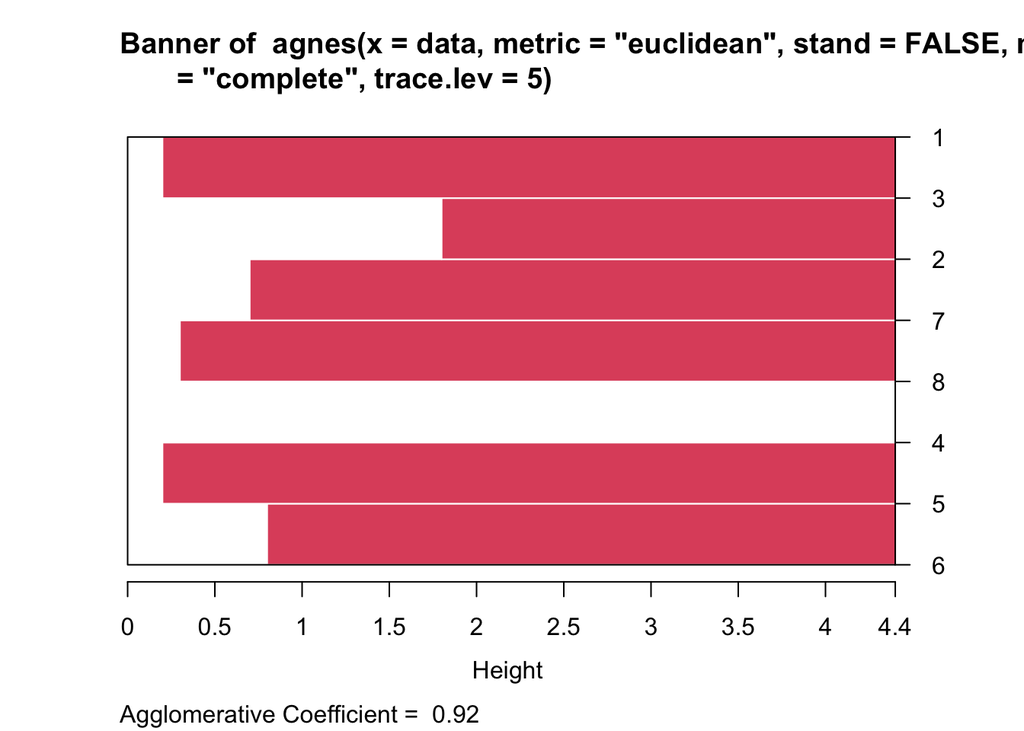

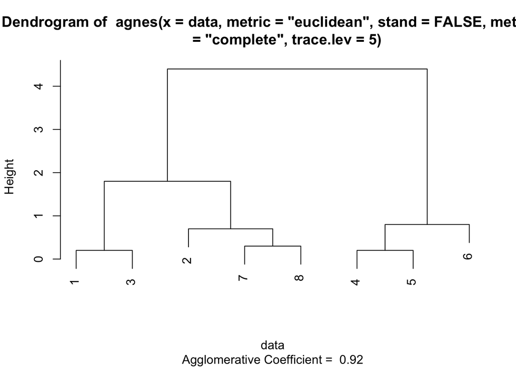

```r
plot(agglom_complete)
```

```r
agglom_average = agnes(data, metric="euclidean", stand=FALSE, method="average", trace.lev = 5)
```

```
## C agnes(n=8, method = 1, ..): 7 merging steps
##  nmerge=0, j=2, d_min = D(1,3) = 0.200000;  -> (-1,-3); last=3; upd(n,b);
##  old D(A, j), D(B, j), j=2  = (1.1,0.9);  new D(A', 2) = 1
##  old D(A, j), D(B, j), j=4  = (4.2,4);  new D(A', 4) = 4.1
##  old D(A, j), D(B, j), j=5  = (4.4,4.2);  new D(A', 5) = 4.3
##  old D(A, j), D(B, j), j=6  = (3.6,3.4);  new D(A', 6) = 3.5
##  old D(A, j), D(B, j), j=7  = (1.5,1.3);  new D(A', 7) = 1.4
##  old D(A, j), D(B, j), j=8  = (1.8,1.6);  new D(A', 8) = 1.7
##  -->  size(A_new)= 2
##  nmerge=1, j=2, d_min = D(4,5) = 0.200000;  -> (-4,-5); last=5;
##  old D(A, j), D(B, j), j=1  = (4.1,4.3);  new D(A', 1) = 4.2
##  old D(A, j), D(B, j), j=2  = (3.1,3.3);  new D(A', 2) = 3.2
##  old D(A, j), D(B, j), j=6  = (0.6,0.8);  new D(A', 6) = 0.7
##  old D(A, j), D(B, j), j=7  = (2.7,2.9);  new D(A', 7) = 2.8
##  old D(A, j), D(B, j), j=8  = (2.4,2.6);  new D(A', 8) = 2.5
##  -->  size(A_new)= 2
##  nmerge=2, j=2, d_min = D(7,8) = 0.300000;  -> (-7,-8); last=8;
##  old D(A, j), D(B, j), j=1  = (1.4,1.7);  new D(A', 1) = 1.55
##  old D(A, j), D(B, j), j=2  = (0.4,0.7);  new D(A', 2) = 0.55
##  old D(A, j), D(B, j), j=4  = (2.8,2.5);  new D(A', 4) = 2.65
##  old D(A, j), D(B, j), j=6  = (2.1,1.8);  new D(A', 6) = 1.95
##  -->  size(A_new)= 2
##  nmerge=3, j=2, d_min = D(2,7) = 0.550000;  -> (-2,3); last=7; upd(n,b);
##  old D(A, j), D(B, j), j=1  = (1,1.55);  new D(A', 1) = 1.36667
##  old D(A, j), D(B, j), j=4  = (3.2,2.65);  new D(A', 4) = 2.83333
##  old D(A, j), D(B, j), j=6  = (2.5,1.95);  new D(A', 6) = 2.13333
##  -->  size(A_new)= 3
##  nmerge=4, j=2, d_min = D(4,6) = 0.700000;  -> (2,-6); last=8;
##  old D(A, j), D(B, j), j=1  = (4.2,3.5);  new D(A', 1) = 3.96667
##  old D(A, j), D(B, j), j=2  = (2.83333,2.13333);  new D(A', 2) = 2.6
##  -->  size(A_new)= 3
##  nmerge=5, j=2, d_min = D(1,2) = 1.36667;  -> (1,4); last=3;
##  old D(A, j), D(B, j), j=4  = (3.96667,2.6);  new D(A', 4) = 3.14667
##  -->  size(A_new)= 5
##  nmerge=6, j=4, d_min = D(1,4) = 3.14667;  -> (6,5); last=6;
##  -->  size(A_new)= 8
```

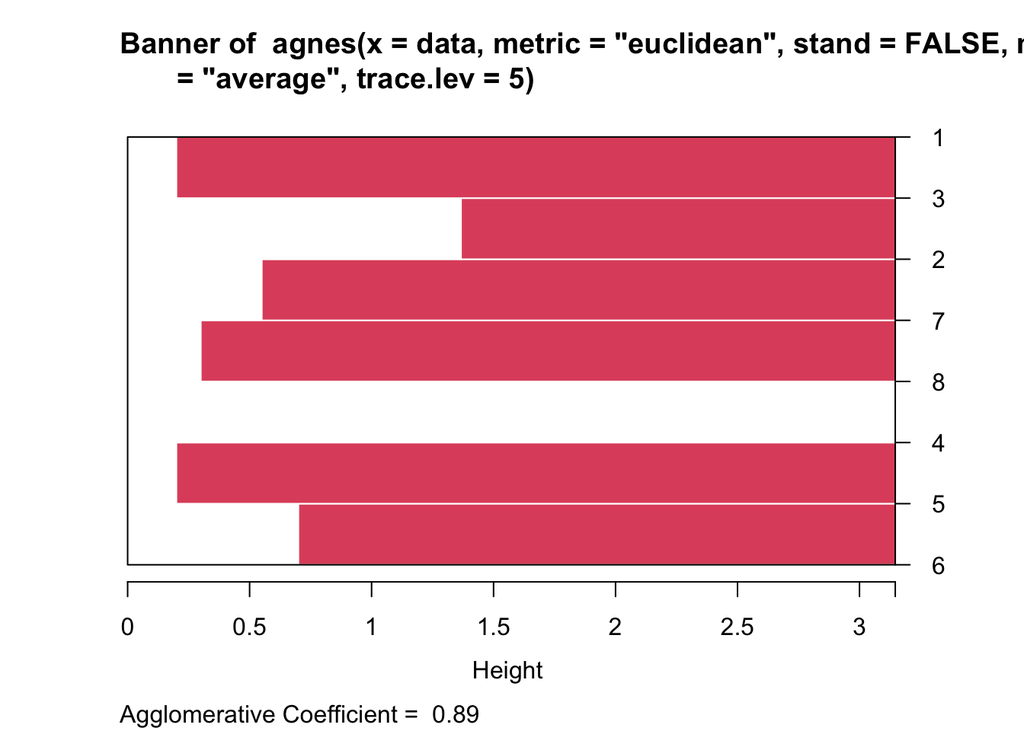

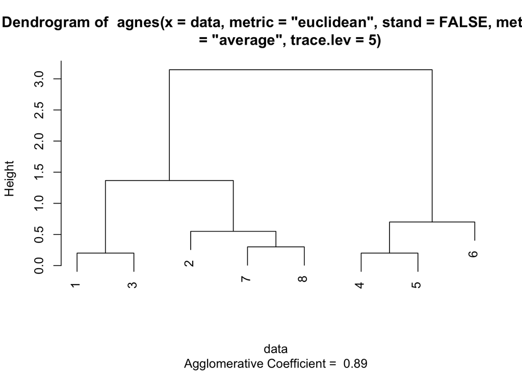

```r
plot(agglom_average)
```

- Agglomerative coefficient measures strength of clustering, through average of normalized lengths of dendrogram - Dimensionless between 0 and 1 - The nearer to one the better

### Combinatorial Algorithms

- Characterized by a many-to-one mapping or encoder $k=c(i)$ that assigns the ith observation to the k-th cluster
- $c(i)$ is determined by finding the one that will minimize a “loss” function
- A natural loss functions is what we refer to as the “within-cluster” distance $W(c)= T-B(c)$